# Practicum 8: Regression

Data Science for Biomedical Informatics (BMIN503/EPID600)

There are no new packages to install for this practicum. ***

We will measure statistical relationships among variables using linear and logistic regression analyses. Additionally, we will cover basic correlation measures and how to visualize computed models in simple terms. We will continue to use the NHANES dataset with additional columns corresponding to: wheezing, asthma, volatile organic compounds a person was exposed to in 24-48 hours, and two pulmonary function measures (i.e., forced expiratory volume in one second (FEV1) and forced vital capacity (FVC)). More details are in the [data dictionary](https://github.com/HimesGroup/BMIN503/blob/master/DataFiles/NHANES_2007to2008_DataDictionary.md).

```r
library(dplyr)
library(ggplot2)
nhanes <- read.csv(url("https://raw.githubusercontent.com/HimesGroup/BMIN503/master/DataFiles/NHANES_2007to2008.csv"), header=TRUE)
nhanes <- rename(nhanes, id=SEQN, gender=RIAGENDR, age=RIDAGEYR, race=RIDRETH1, education=DMDEDUC2, income=INDHHIN2, health.provider=HUQ040, wheezing=RDQ070, asthma=MCQ010, voc=WTSVOC2Y, fvc=SPXNFVC, fev1=SPXNFEV1) %>%
    mutate(gender=factor(gender, levels=c(1, 2), labels=c("male", "female"))) %>%
    mutate(race=factor(race, levels=c(3, 1, 2, 4, 5), labels=c("white", "MexicanAmerican", "Hispanic", "black", "other"))) %>%
    mutate(asthma=ifelse(asthma %in% c(7,9), NA, ifelse(asthma==2, 0, 1))) %>%
    filter(!is.na(asthma))
str(nhanes)
```

```
## 'data.frame':    9659 obs. of  12 variables:
##  $ id             : int  41475 41476 41477 41478 41479 41480 41481 41482 41483 41485 ...
##  $ gender         : Factor w/ 2 levels "male","female": 2 2 1 2 1 1 1 1 1 2 ...
##  $ age            : int  62 6 71 1 52 6 21 64 66 30 ...
##  $ race           : Factor w/ 5 levels "white","MexicanAmerican",..: 5 5 1 1 2 2 4 2 4 3 ...
##  $ education      : int  3 NA 3 NA 1 NA 3 2 4 2 ...
##  $ income         : int  6 15 5 3 8 7 6 15 5 6 ...
##  $ health.provider: int  1 2 1 2 2 1 1 1 2 NA ...
##  $ wheezing       : int  1 2 2 2 2 2 2 2 2 2 ...
##  $ asthma         : num  1 0 0 0 0 0 0 0 0 0 ...
##  $ voc            : num  123988 NA 20915 NA NA ...
##  $ fvc            : int  2473 1742 NA NA 3545 1836 4928 3907 3170 NA ...
##  $ fev1           : int  2025 1551 NA NA 2957 1691 4541 2920 2355 NA ...
```

### Correlation

After inspecting 2D scatter plots of two continuous variables, we may notice a linear trend among them. To quantify such a trend, we can measure correlation. Recall that Pearson correlation is often the default correlation measure, and it is only appropriate for linearly related variables. The closer to |1|, the greater the relationship resembles a perfectly linear one.

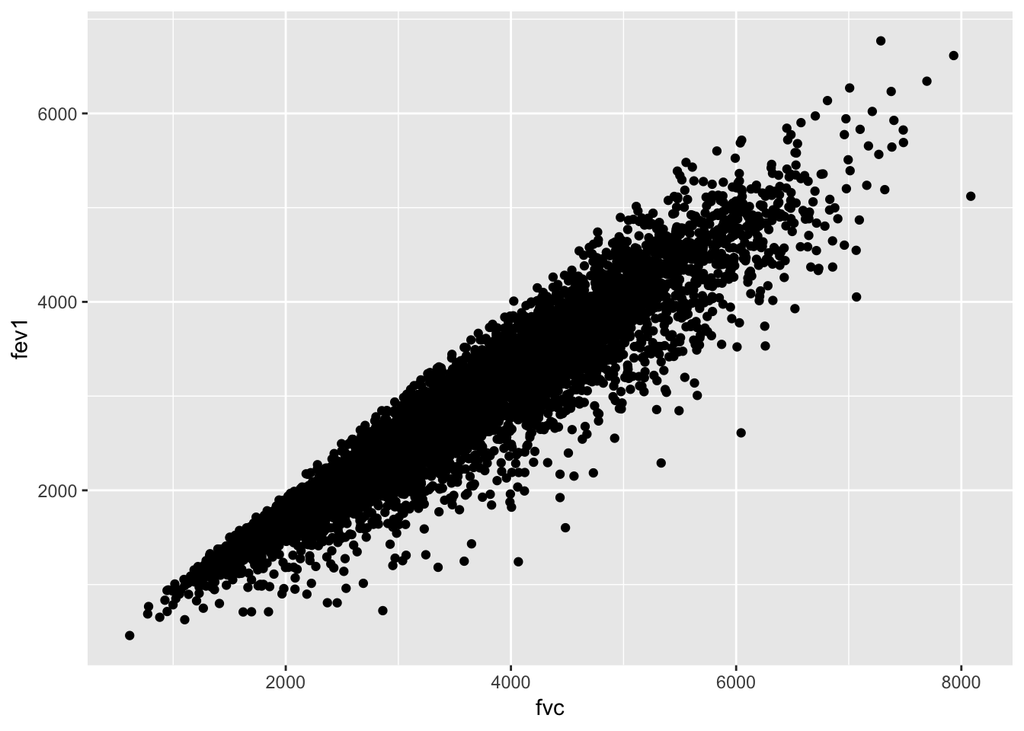

```r
ggplot(data=nhanes, aes(x=fvc, y=fev1)) +
    geom_point()
```

```r
cor(nhanes$fev1, nhanes$fvc, use="complete.obs") #Default method is Pearson
```

```
## [1] 0.9450629
```

```r
cor(nhanes$fev1, nhanes$fvc, use="complete.obs", method="spearman") #Rank-based correlation
```

```
## [1] 0.9472963
```

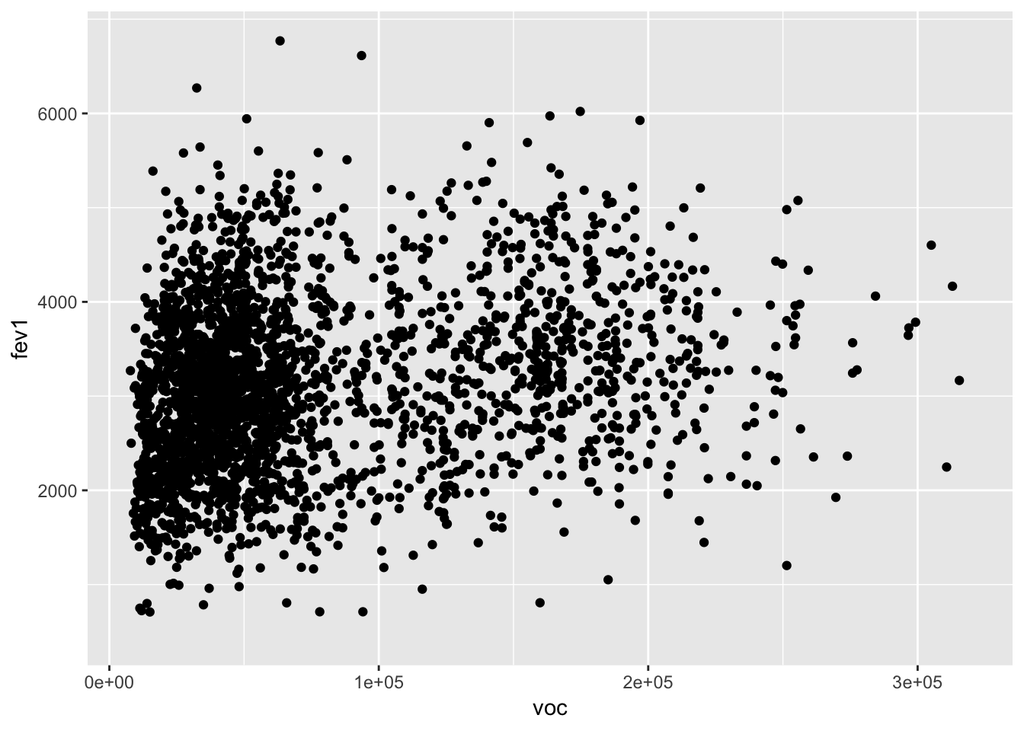

```r
ggplot(data=nhanes, aes(x=voc, y=fev1)) +
    geom_point()
```

```r
cor(nhanes$fev1, nhanes$voc, use="complete.obs")
```

```
## [1] 0.2232592
```

### Simulated Data

We’ve used simulated data in previous lectures, and here we will describe how to generate random data according to common probability distributions. For normaly distributed variables, we can use `rnorm`, which generates random deviates according to the normal distribution given a mean and standard deviation, while `dnorm` gives the density of the distribution. For binary outcome variables, we can use `rbinom`, which generates variates according to the binomial distribution given *n* independent experiments with success probability *p*.

If generating random numbers to do a simulation, use `set.seed()` to ensure that the same numbers are generated for a call.

```r
rnorm(4)
```

```
## [1] -1.3516336  2.0098481 -1.2515453  0.3210527
```

```r
set.seed(1234)
rnorm(4)
```

```
## [1] -1.2070657  0.2774292  1.0844412 -2.3456977
```

```r
rnorm(4)
```

```
## [1]  0.4291247  0.5060559 -0.5747400 -0.5466319
```

```r
set.seed(1234)
rnorm(4) #The same "random" data as above is output
```

```
## [1] -1.2070657  0.2774292  1.0844412 -2.3456977
```

Let’s get some points that are randomly drawn from a normal distribution.

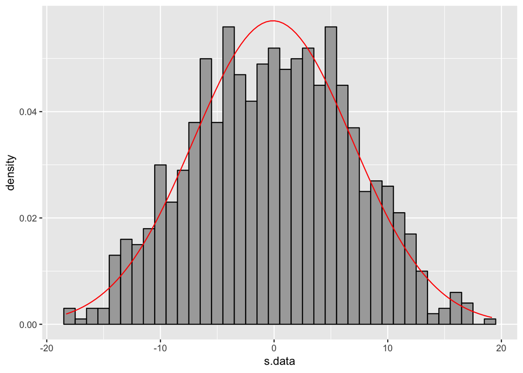

```r
#Randomly distributed data
x.vals <- seq(-5, 5, 0.01)
s.data <- 2*x.vals + rnorm(length(x.vals), 0, 4) #Random normal distribution
df <- data.frame(x=x.vals, s=s.data)
ggplot() +
    aes(s.data) +
    geom_histogram(aes(y=..density..), binwidth=1, color="black", fill="darkgrey") +
    stat_function(fun = dnorm, color="red", args = list(mean=mean(s.data), sd=sd(s.data)))
```

We can use `rnorm` to simulate dependent variables in a linear model. Say we are interested in simulating a model where outcome $y$ depends on variable $x$ subject to some noise $\epsilon$:

$$y = \beta_{0} + \beta_{1}x + \epsilon$$

where $\epsilon \sim \mathcal{N}(0,2^{2})$, $x \sim \mathcal{N}(0,1^{2})$, $\beta_{0}=0.5$, and $\beta_{1}=2$.

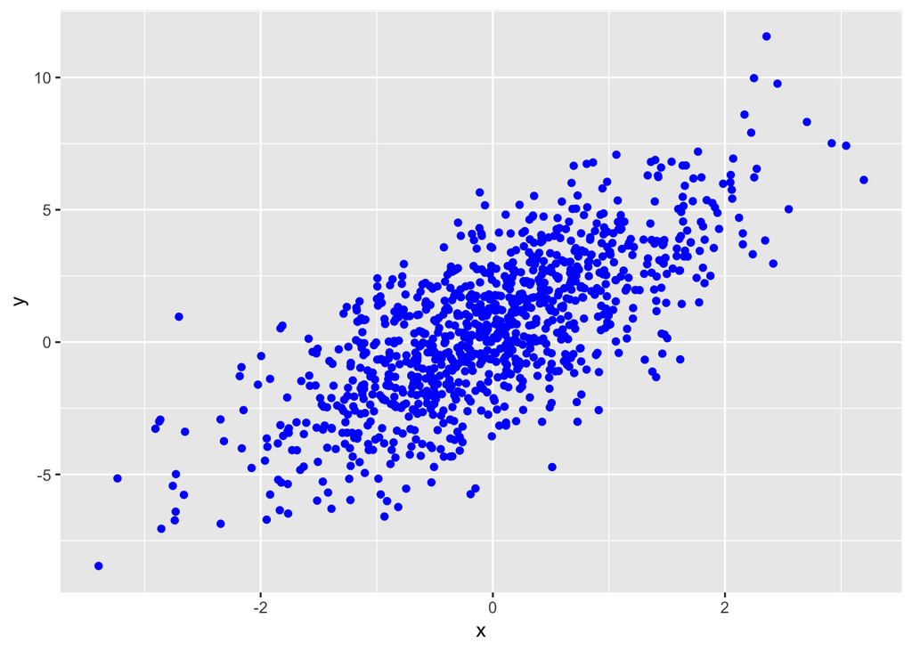

```r
set.seed(1234)
x.normal <- rnorm(1000)
e <- rnorm(1000, 0, 2)
y.lin <- 0.5 + 2*x.normal + e
df <- data.frame(x=x.normal, y=y.lin)

ggplot(df, aes(x=x, y=y)) +
    geom_point(color="blue")
```

If x were a binary variable, like gender, we could simulate it using `rbinom`, which corresponds to the binomial distribution.

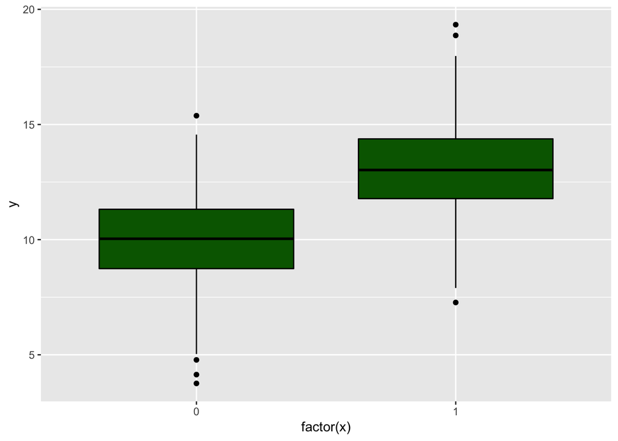

```r
x.binomial <- rbinom(1000, 1, 0.5)
y.linb <- 10 + 3*x.binomial + e
dfb <- data.frame(x=x.binomial, y=y.linb)

ggplot(dfb, aes(x=factor(x), y=y)) +
    geom_boxplot(color="black", fill="darkgreen")
```

More generally, random data can be generated with `sample`, which takes a set of values and randomly draws from them according to other parameters set in the function.

```r
sample(1:20, 5) #Sample without replacement
```

```
## [1]  2  4 13 12 20
```

```r
sample(1:20, 5)
```

```
## [1] 15  8 19  1 20
```

```r
sample(1:10) #Permutation
```

```
##  [1]  1  3  2  8  4  5  9 10  7  6
```

```r
sample(1:10)
```

```
##  [1]  7  2  6 10  9  1  5  3  4  8
```

```r
sample(1:5, 5, replace=TRUE) #Sample with replacement
```

```
## [1] 1 3 3 1 3
```

```r
sample(1:5, 5, replace=TRUE)
```

```
## [1] 3 2 1 3 1
```

```r
set.seed(1234) #Recall that set.seed can be used to get same output
sample(1:5, 5, replace=TRUE)
```

```
## [1] 1 4 4 4 5
```

```r
set.seed(1234)
sample(1:5, 5, replace=TRUE)
```

```
## [1] 1 4 4 4 5
```

### Linear Models

The most common function used to fit linear models, where the outcome is a continuous variable, in R is `lm`. The summary output is retrieved with `summary`. Let’s first review our simulated data that we know will fit a linear model nicely.

```r
test.fit <- lm(y.lin ~ x.normal)
summary(test.fit)
```

```
##
## Call:
## lm(formula = y.lin ~ x.normal)
##
## Residuals:
##    Min     1Q Median     3Q    Max
## -6.332 -1.288  0.029  1.307  6.137
##
## Coefficients:
##             Estimate Std. Error t value Pr(>|t|)
## (Intercept)  0.53198    0.06201   8.579   <2e-16 ***
## x.normal     2.11143    0.06218  33.954   <2e-16 ***
## ---
## Signif. codes:  0 '***' 0.001 '**' 0.01 '*' 0.05 '.' 0.1 ' ' 1
##
## Residual standard error: 1.96 on 998 degrees of freedom
## Multiple R-squared:  0.536,  Adjusted R-squared:  0.5355
## F-statistic:  1153 on 1 and 998 DF,  p-value: < 2.2e-16
```

```r
coef(test.fit) #We recover the intercept and coefficient for x that are expected
```

```
## (Intercept)    x.normal
##   0.5319801   2.1114266
```

```r
confint(test.fit) #Confidence intervals for fit
```

```
##                2.5 %    97.5 %
## (Intercept) 0.410296 0.6536643
## x.normal    1.989400 2.2334532
```

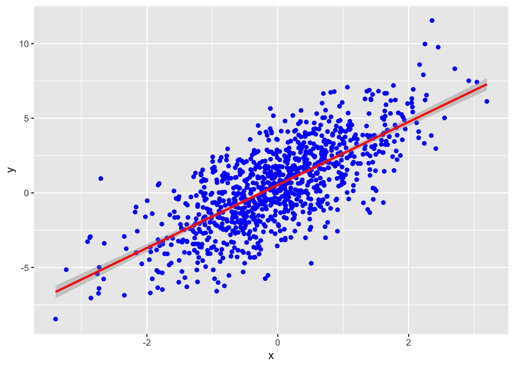

```r
ggplot(df, aes(x=x, y=y)) +
    geom_point(color="blue") +
    geom_smooth(method = "lm", color="red")
```

```r
test.fit <- lm(y.linb ~ x.binomial)
summary(test.fit)
```

```
##
## Call:
## lm(formula = y.linb ~ x.binomial)
##
## Residuals:
##     Min      1Q  Median      3Q     Max
## -6.2098 -1.2741 -0.0079  1.3228  6.2464
##
## Coefficients:
##             Estimate Std. Error t value Pr(>|t|)
## (Intercept)  9.96664    0.08847  112.65   <2e-16 ***
## x.binomial   3.12278    0.12413   25.16   <2e-16 ***
## ---
## Signif. codes:  0 '***' 0.001 '**' 0.01 '*' 0.05 '.' 0.1 ' ' 1
##
## Residual standard error: 1.962 on 998 degrees of freedom
## Multiple R-squared:  0.3881, Adjusted R-squared:  0.3875
## F-statistic: 632.9 on 1 and 998 DF,  p-value: < 2.2e-16
```

```r
coef(test.fit) #We recover the intercept and coefficient for x that are expected
```

```
## (Intercept)  x.binomial
##    9.966643    3.122783
```

```r
confint(test.fit) #Confidence intervals for fit
```

```
##                2.5 %    97.5 %
## (Intercept) 9.793030 10.140256
## x.binomial  2.879198  3.366367
```

Based on our previous fev1 vs. fvc plot and correlation measures, we know a linear model is appropriate to model the relationship between them.

```r
fev1.lm.fit <- lm(fev1 ~ fvc, data=nhanes)
fev1.lm.fit
```

```
##
## Call:
## lm(formula = fev1 ~ fvc, data = nhanes)
##
## Coefficients:
## (Intercept)          fvc
##    144.4868       0.7598
```

```r
summary.fev1.lm.fit <- summary.lm(fev1.lm.fit) #Summary of results
summary.fev1.lm.fit
```

```
##
## Call:
## lm(formula = fev1 ~ fvc, data = nhanes)
##
## Residuals:
##      Min       1Q   Median       3Q      Max
## -2126.70  -153.72    31.29   182.49  1114.84
##
## Coefficients:
##              Estimate Std. Error t value Pr(>|t|)
## (Intercept) 1.445e+02  1.268e+01   11.39   <2e-16 ***
## fvc         7.598e-01  3.308e-03  229.69   <2e-16 ***
## ---
## Signif. codes:  0 '***' 0.001 '**' 0.01 '*' 0.05 '.' 0.1 ' ' 1
##
## Residual standard error: 318.5 on 6312 degrees of freedom
##   (3345 observations deleted due to missingness)
## Multiple R-squared:  0.8931, Adjusted R-squared:  0.8931
## F-statistic: 5.276e+04 on 1 and 6312 DF,  p-value: < 2.2e-16
```

```r
names(summary.fev1.lm.fit) #We can retrieve output from summary statistics for model fit
```

```
##  [1] "call"          "terms"         "residuals"     "coefficients"  "aliased"       "sigma"         "df"            "r.squared"     "adj.r.squared" "fstatistic"    "cov.unscaled"  "na.action"
```

```r
summary.fev1.lm.fit$adj.r.squared
```

```
## [1] 0.8931269
```

```r
confint(fev1.lm.fit) #Confidence intervals for fit
```

```
##                   2.5 %      97.5 %
## (Intercept) 119.6263170 169.3472538
## fvc           0.7533122   0.7662815
```

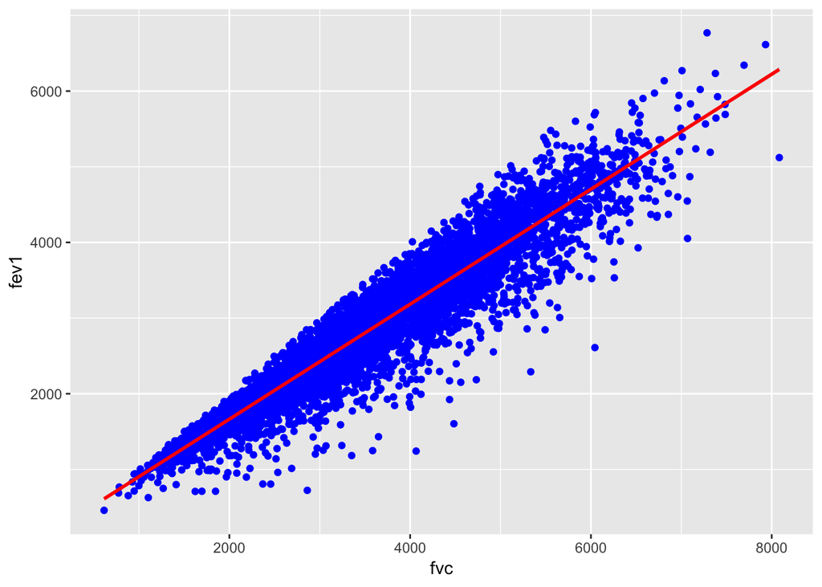

```r
ggplot(nhanes, aes(x=fvc, y=fev1)) +
    geom_point(color="blue") +
    geom_smooth(method = "lm", color="red")
```

What about other demographic variables?

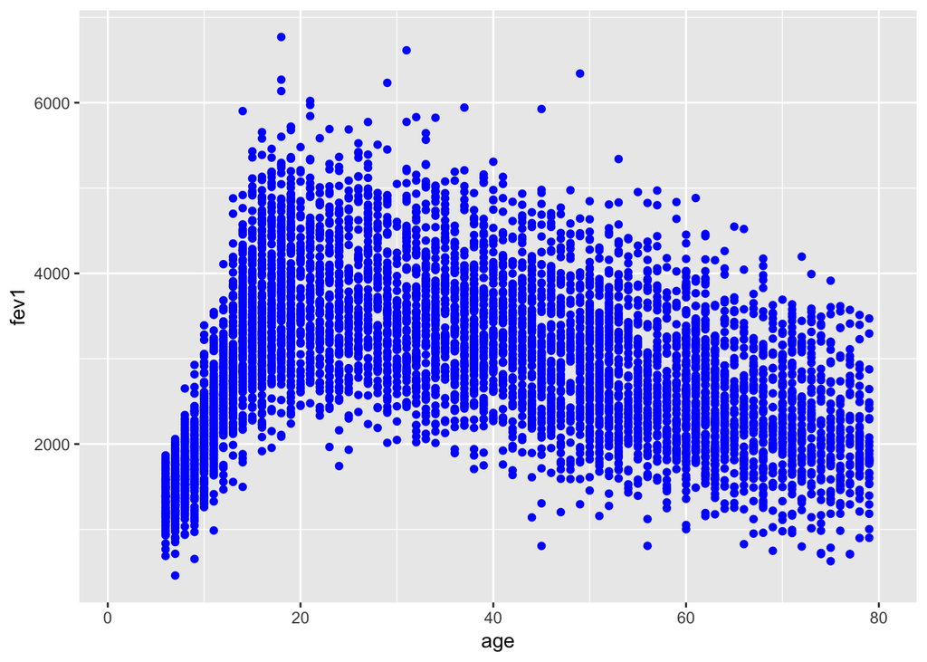

```r
ggplot(nhanes, aes(x=age, y=fev1)) +
    geom_point(color="blue")
```

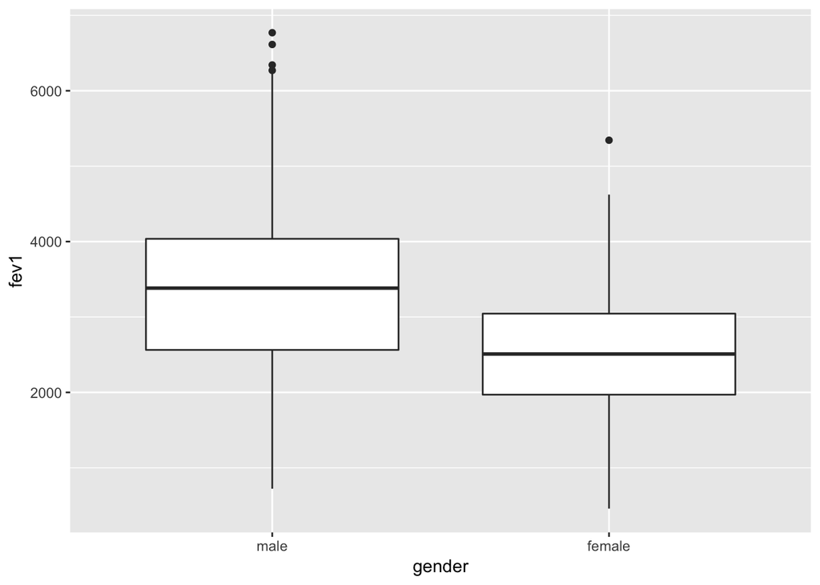

```r
ggplot(nhanes, aes(x=gender, y=fev1)) +
    geom_boxplot()
```

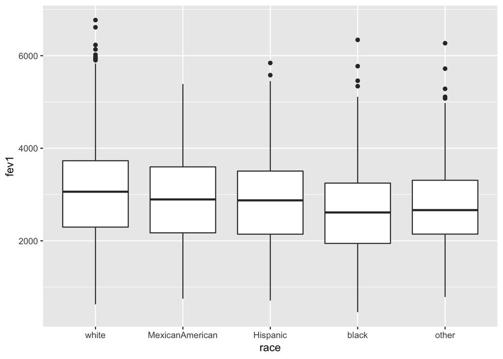

```r
ggplot(nhanes, aes(x=race, y=fev1)) +
    geom_boxplot()
```

```r
summary((lm(fev1~age, data=nhanes)))
```

```
##
## Call:
## lm(formula = fev1 ~ age, data = nhanes)
##
## Residuals:
##     Min      1Q  Median      3Q     Max
## -2527.8  -727.1   -26.1   665.5  3813.1
##
## Coefficients:
##              Estimate Std. Error t value Pr(>|t|)
## (Intercept) 3005.8010    23.8733 125.907  < 2e-16 ***
## age           -2.7185     0.5697  -4.772 1.87e-06 ***
## ---
## Signif. codes:  0 '***' 0.001 '**' 0.01 '*' 0.05 '.' 0.1 ' ' 1
##
## Residual standard error: 972.7 on 6312 degrees of freedom
##   (3345 observations deleted due to missingness)
## Multiple R-squared:  0.003595,   Adjusted R-squared:  0.003437
## F-statistic: 22.77 on 1 and 6312 DF,  p-value: 1.866e-06
```

```r
summary((lm(fev1~gender, data=nhanes)))
```

```
##
## Call:
## lm(formula = fev1 ~ gender, data = nhanes)
##
## Residuals:
##     Min      1Q  Median      3Q     Max
## -2575.5  -613.1    38.5   632.5  3471.5
##
## Coefficients:
##              Estimate Std. Error t value Pr(>|t|)
## (Intercept)   3298.46      15.76  209.27   <2e-16 ***
## genderfemale  -790.19      22.42  -35.24   <2e-16 ***
## ---
## Signif. codes:  0 '***' 0.001 '**' 0.01 '*' 0.05 '.' 0.1 ' ' 1
##
## Residual standard error: 890.8 on 6312 degrees of freedom
##   (3345 observations deleted due to missingness)
## Multiple R-squared:  0.1644, Adjusted R-squared:  0.1643
## F-statistic:  1242 on 1 and 6312 DF,  p-value: < 2.2e-16
```

```r
summary((lm(fev1~race, data=nhanes)))
```

```
##
## Call:
## lm(formula = fev1 ~ race, data = nhanes)
##
## Residuals:
##     Min      1Q  Median      3Q     Max
## -2444.6  -739.6   -23.3   646.7  3698.4
##
## Coefficients:
##                     Estimate Std. Error t value Pr(>|t|)
## (Intercept)          3071.65      18.79 163.456  < 2e-16 ***
## raceMexicanAmerican  -160.43      32.62  -4.919 8.92e-07 ***
## raceHispanic         -211.09      39.90  -5.290 1.26e-07 ***
## raceblack            -422.78      31.85 -13.274  < 2e-16 ***
## raceother            -297.74      62.48  -4.765 1.93e-06 ***
## ---
## Signif. codes:  0 '***' 0.001 '**' 0.01 '*' 0.05 '.' 0.1 ' ' 1
##
## Residual standard error: 960.8 on 6309 degrees of freedom
##   (3345 observations deleted due to missingness)
## Multiple R-squared:  0.02838,    Adjusted R-squared:  0.02776
## F-statistic: 46.07 on 4 and 6309 DF,  p-value: < 2.2e-16
```

We might try a combined model to see whether the slope of fvc changes by gender, or whether there is an interaction between fvc and gender.

```r
summary.lm(lm(fev1 ~ fvc + gender, data=nhanes))
```

```
##
## Call:
## lm(formula = fev1 ~ fvc + gender, data = nhanes)
##
## Residuals:
##      Min       1Q   Median       3Q      Max
## -2124.22  -157.54    32.81   185.02  1122.48
##
## Coefficients:
##              Estimate Std. Error t value Pr(>|t|)
## (Intercept)   78.2631    16.4558   4.756 2.02e-06 ***
## fvc            0.7703     0.0037 208.203  < 2e-16 ***
## genderfemale  56.3880     8.9686   6.287 3.45e-10 ***
## ---
## Signif. codes:  0 '***' 0.001 '**' 0.01 '*' 0.05 '.' 0.1 ' ' 1
##
## Residual standard error: 317.6 on 6311 degrees of freedom
##   (3345 observations deleted due to missingness)
## Multiple R-squared:  0.8938, Adjusted R-squared:  0.8938
## F-statistic: 2.656e+04 on 2 and 6311 DF,  p-value: < 2.2e-16
```

```r
summary.lm(lm(fev1 ~ fvc + gender + fvc:gender, data=nhanes))
```

```
##
## Call:
## lm(formula = fev1 ~ fvc + gender + fvc:gender, data = nhanes)
##
## Residuals:
##      Min       1Q   Median       3Q      Max
## -2098.50  -156.76    31.11   184.13  1141.45
##
## Coefficients:
##                    Estimate Std. Error t value Pr(>|t|)
## (Intercept)       1.360e+02  1.928e+01   7.051 1.97e-12 ***
## fvc               7.565e-01  4.413e-03 171.423  < 2e-16 ***
## genderfemale     -1.002e+02  2.888e+01  -3.470 0.000524 ***
## fvc:genderfemale  4.591e-02  8.049e-03   5.703 1.23e-08 ***
## ---
## Signif. codes:  0 '***' 0.001 '**' 0.01 '*' 0.05 '.' 0.1 ' ' 1
##
## Residual standard error: 316.8 on 6310 degrees of freedom
##   (3345 observations deleted due to missingness)
## Multiple R-squared:  0.8944, Adjusted R-squared:  0.8943
## F-statistic: 1.781e+04 on 3 and 6310 DF,  p-value: < 2.2e-16
```

### Logistic Regression Models

To fit a model to a binary outcome, we can use the `glm` function with the *binomial* family as the type of function to be used for the fit. The summary output is retrieved with `summary`. We’ll use the NHANES dataset with asthma as a binary outcome to illustrate these models. An option to test univariate relationships with dependent categorical variables is a Pearson’s Chi-square test, another is a logistic regression model.

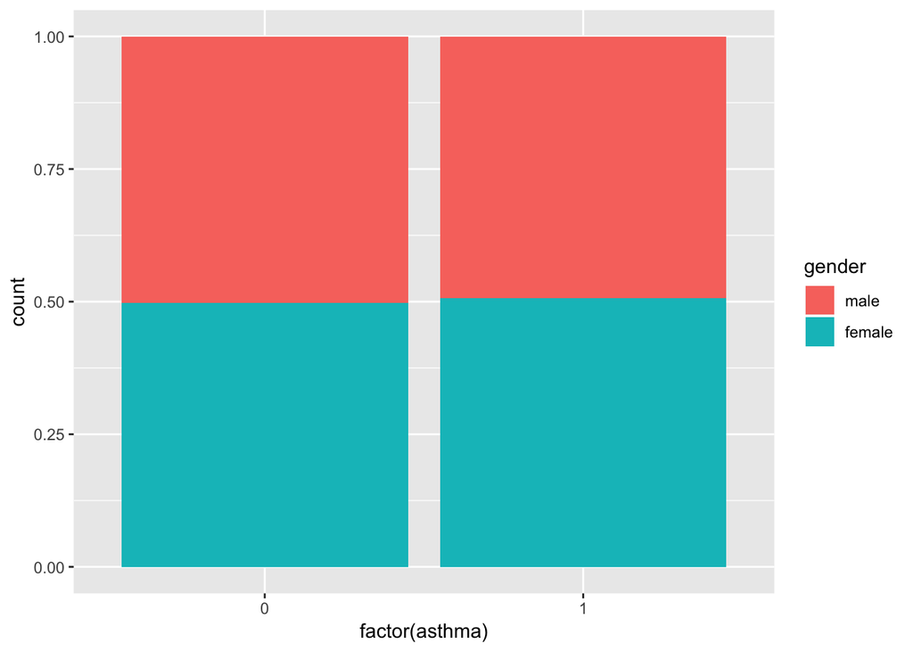

```r
ggplot(data=nhanes, aes(x=factor(asthma), fill=gender)) +
    geom_bar(position="fill")
```

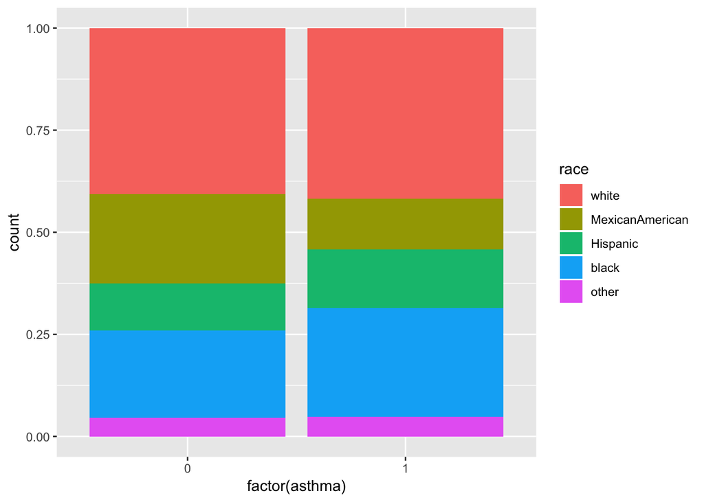

```r
ggplot(data=nhanes, aes(x=factor(asthma), fill=race)) +
    geom_bar(position="fill")
```

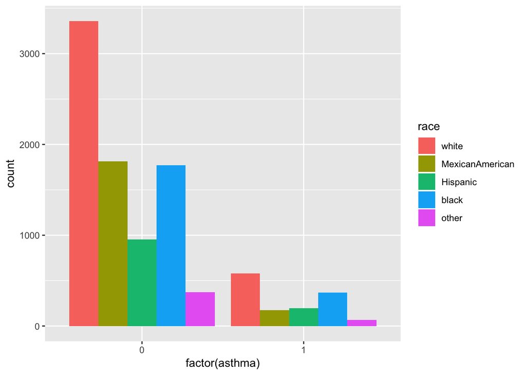

```r
ggplot(data=nhanes, aes(x=factor(asthma), fill=race)) +
    geom_bar(position="dodge")
```

```r
chisq.test(table(nhanes$asthma, nhanes$gender))
```

```
##
##  Pearson's Chi-squared test with Yates' continuity correction
##
## data:  table(nhanes$asthma, nhanes$gender)
## X-squared = 0.34251, df = 1, p-value = 0.5584
```

```r
summary((glm(asthma~gender, data=nhanes, family=binomial())))
```

```
##
## Call:
## glm(formula = asthma ~ gender, family = binomial(), data = nhanes)
##
## Deviance Residuals:
##     Min       1Q   Median       3Q      Max
## -0.5610  -0.5610  -0.5518  -0.5518   1.9787
##
## Coefficients:
##              Estimate Std. Error z value Pr(>|z|)
## (Intercept)  -1.80531    0.04126 -43.755   <2e-16 ***
## genderfemale  0.03567    0.05807   0.614    0.539
## ---
## Signif. codes:  0 '***' 0.001 '**' 0.01 '*' 0.05 '.' 0.1 ' ' 1
##
## (Dispersion parameter for binomial family taken to be 1)
##
##     Null deviance: 7941.0  on 9658  degrees of freedom
## Residual deviance: 7940.7  on 9657  degrees of freedom
## AIC: 7944.7
##
## Number of Fisher Scoring iterations: 4
```

```r
exp(coef(glm(asthma~gender, data=nhanes, family=binomial()))) #Odds ratios
```

```
##  (Intercept) genderfemale
##    0.1644231    1.0363130
```

```r
chisq.test(table(nhanes$asthma, nhanes$race))
```

```
##
##  Pearson's Chi-squared test
##
## data:  table(nhanes$asthma, nhanes$race)
## X-squared = 74.591, df = 4, p-value = 2.431e-15
```

```r
summary((glm(asthma~race, data=nhanes, family=binomial())))
```

```
##
## Call:
## glm(formula = asthma ~ race, family = binomial(), data = nhanes)
##
## Deviance Residuals:
##     Min       1Q   Median       3Q      Max
## -0.6157  -0.6145  -0.5634  -0.4267   2.2098
##
## Coefficients:
##                     Estimate Std. Error z value Pr(>|z|)
## (Intercept)         -1.76012    0.04503 -39.088  < 2e-16 ***
## raceMexicanAmerican -0.59043    0.09143  -6.458 1.06e-10 ***
## raceHispanic         0.18877    0.09015   2.094  0.03627 *
## raceblack            0.19320    0.07276   2.655  0.00793 **
## raceother            0.02820    0.14093   0.200  0.84141
## ---
## Signif. codes:  0 '***' 0.001 '**' 0.01 '*' 0.05 '.' 0.1 ' ' 1
##
## (Dispersion parameter for binomial family taken to be 1)
##
##     Null deviance: 7941.0  on 9658  degrees of freedom
## Residual deviance: 7860.5  on 9654  degrees of freedom
## AIC: 7870.5
##
## Number of Fisher Scoring iterations: 5
```

To test for univariable association with dependent continuous variables a logistic regression with a single independent predictor can be used.

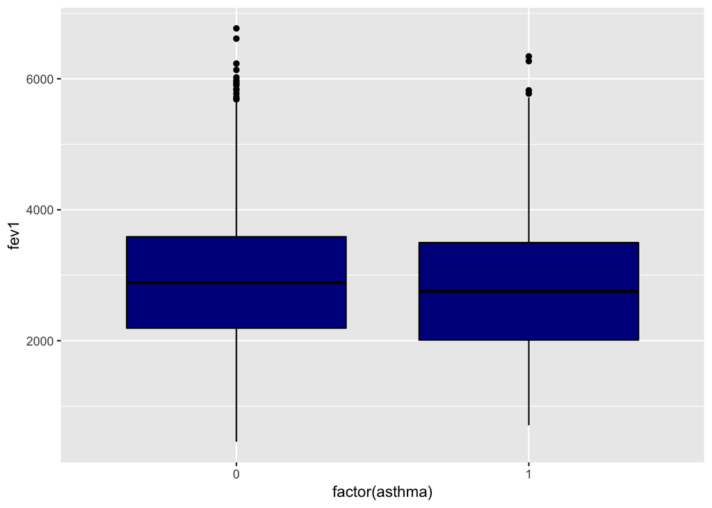

```r
ggplot(data=nhanes, aes(x=factor(asthma), y=fev1)) +
    geom_boxplot(color="black", fill="darkblue")
```

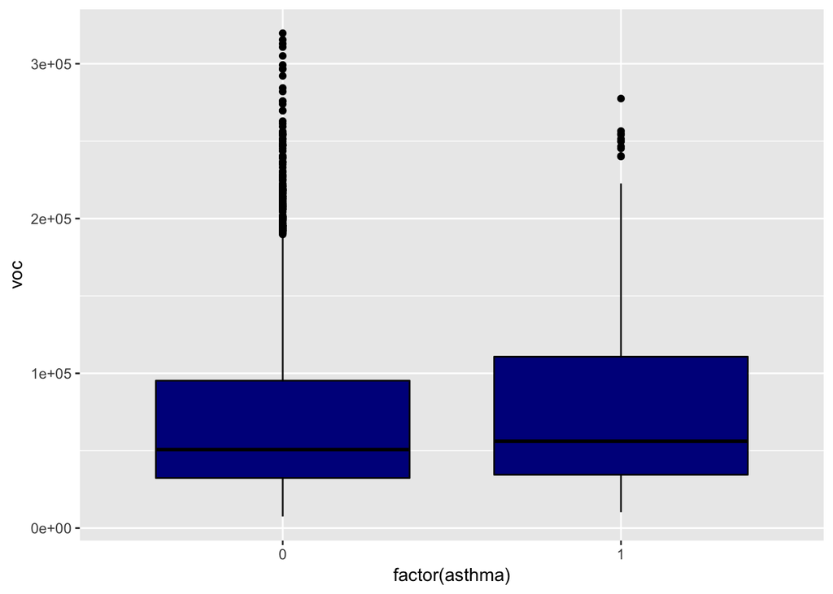

```r
ggplot(data=nhanes, aes(x=factor(asthma), y=voc)) +
    geom_boxplot(color="black", fill="darkblue")
```

```r
summary((glm(asthma~fev1, data=nhanes, family=binomial())))
```

```
##
## Call:
## glm(formula = asthma ~ fev1, family = binomial(), data = nhanes)
##
## Deviance Residuals:
##     Min       1Q   Median       3Q      Max
## -0.6589  -0.5821  -0.5508  -0.5152   2.1815
##
## Coefficients:
##               Estimate Std. Error z value Pr(>|z|)
## (Intercept) -1.349e+00  1.108e-01 -12.182  < 2e-16 ***
## fev1        -1.471e-04  3.731e-05  -3.943 8.05e-05 ***
## ---
## Signif. codes:  0 '***' 0.001 '**' 0.01 '*' 0.05 '.' 0.1 ' ' 1
##
## (Dispersion parameter for binomial family taken to be 1)
##
##     Null deviance: 5239.5  on 6313  degrees of freedom
## Residual deviance: 5223.7  on 6312  degrees of freedom
##   (3345 observations deleted due to missingness)
## AIC: 5227.7
##
## Number of Fisher Scoring iterations: 4
```

```r
summary((glm(asthma~voc, data=nhanes, family=binomial())))
```

```
##
## Call:
## glm(formula = asthma ~ voc, family = binomial(), data = nhanes)
##
## Deviance Residuals:
##     Min       1Q   Median       3Q      Max
## -0.6385  -0.5440  -0.5321  -0.5242   2.0339
##
## Coefficients:
##               Estimate Std. Error z value Pr(>|z|)
## (Intercept) -1.948e+00  8.095e-02 -24.068   <2e-16 ***
## voc          1.443e-06  8.219e-07   1.756   0.0791 .
## ---
## Signif. codes:  0 '***' 0.001 '**' 0.01 '*' 0.05 '.' 0.1 ' ' 1
##
## (Dispersion parameter for binomial family taken to be 1)
##
##     Null deviance: 2693.3  on 3368  degrees of freedom
## Residual deviance: 2690.3  on 3367  degrees of freedom
##   (6290 observations deleted due to missingness)
## AIC: 2694.3
##
## Number of Fisher Scoring iterations: 4
```

We might try a combined model to see whether variable significance changes after adjusting for other variables.

```r
asthma.fit <- glm(asthma ~ fev1 + age + gender + race, data=nhanes, family=binomial())
summary(asthma.fit)
```

```
##
## Call:
## glm(formula = asthma ~ fev1 + age + gender + race, family = binomial(),
##     data = nhanes)
##
## Deviance Residuals:
##     Min       1Q   Median       3Q      Max
## -0.8683  -0.5896  -0.5190  -0.4224   2.4363
##
## Coefficients:
##                       Estimate Std. Error z value Pr(>|z|)
## (Intercept)         -6.884e-01  1.595e-01  -4.316 1.59e-05 ***
## fev1                -1.545e-04  3.987e-05  -3.875 0.000107 ***
## age                 -1.411e-02  1.732e-03  -8.151 3.61e-16 ***
## genderfemale        -8.468e-03  7.730e-02  -0.110 0.912770
## raceMexicanAmerican -7.862e-01  1.135e-01  -6.926 4.32e-12 ***
## raceHispanic        -2.017e-02  1.138e-01  -0.177 0.859343
## raceblack           -1.156e-01  9.386e-02  -1.232 0.217963
## raceother            1.688e-01  1.664e-01   1.014 0.310465
## ---
## Signif. codes:  0 '***' 0.001 '**' 0.01 '*' 0.05 '.' 0.1 ' ' 1
##
## (Dispersion parameter for binomial family taken to be 1)
##
##     Null deviance: 5239.5  on 6313  degrees of freedom
## Residual deviance: 5105.7  on 6306  degrees of freedom
##   (3345 observations deleted due to missingness)
## AIC: 5121.7
##
## Number of Fisher Scoring iterations: 5
```

```r
exp(coef(asthma.fit)) #Odds ratios.
```

```
##         (Intercept)                fev1                 age        genderfemale raceMexicanAmerican        raceHispanic           raceblack           raceother
##           0.5023894           0.9998455           0.9859852           0.9915673           0.4555893           0.9800306           0.8908080           1.1838769
```

```r
confint(asthma.fit) #Confidence intervals for fit
```

```
##                             2.5 %        97.5 %
## (Intercept)         -1.0033928914 -3.780291e-01
## fev1                -0.0002327185 -7.641063e-05
## age                 -0.0175292455 -1.073949e-02
## genderfemale        -0.1598877476  1.432147e-01
## raceMexicanAmerican -1.0122674183 -5.669832e-01
## raceHispanic        -0.2463109549  2.002059e-01
## raceblack           -0.3007342480  6.731679e-02
## raceother           -0.1660111903  4.875575e-01
```

```r
exp(cbind(OR=coef(asthma.fit), CI=confint(asthma.fit))) #OR and 95%CI
```

```
##                            OR     2.5 %    97.5 %
## (Intercept)         0.5023894 0.3666334 0.6852106
## fev1                0.9998455 0.9997673 0.9999236
## age                 0.9859852 0.9826235 0.9893180
## genderfemale        0.9915673 0.8522394 1.1539775
## raceMexicanAmerican 0.4555893 0.3633941 0.5672341
## raceHispanic        0.9800306 0.7816791 1.2216543
## raceblack           0.8908080 0.7402745 1.0696343
## raceother           1.1838769 0.8470368 1.6283341
```

With real data, identifying significant predictors is not always straightforward. Doing a careful exploratory analysis can help you identify potential relationships that are interesting to explore further. In some cases, the relationships are striking and remain no matter how you analyze data, and thus, it is clearer that your result is significant. Remember though, you will have measured an association and not a causal relationship.